# R - przypomnienie

## Wprowadzenie

Notebook ten powstał w celu przypomnienia podstawowych funkcjonalności języka R na pierwszych laboratoriach z przedmiotu *Techniki Wizualizacji Danych*.

Czym są *markdownowe* notebooki?

- ich celem jest interaktywne uruchamianie kawałków kodu w języku *R* i formatowanie tekstu w przyjazny dla użytkownika sposób za pomocą języka *Markdown.*
- w RStudio możemy je wyświetlać w trybie *Source* i *Visual* (lewy górny róg). Tryb *Source* pozwala bezpośrednio korzystać ze składni *Markdowna* i *R*, natomiast *Visual* udostępnia w tym celu dodatkowe API, które teraz widzimy (jeśli jesteśmy w trybie *Visual -* zalecane*).*
- klikając w dowolne miejsce w notebooku, możemy wprowadzić nowy tekst.
- kawałki kodu możemy uruchamiać za pomocą przycisku *Run* po jego prawej stronie, bądź używając *Ctrl+Shift+Enter (Windows)/* *Cmd+Shift+Enter (MacOS)* po kliknięciu na niego.
- aby umieścić nowy kawałek kodu, możemy użyć przycisku *Insert Chunk* z toolbara lub skrótu *Ctrl+Alt+I* (Windows) / *Cmd+Option+I (MacOS).*

Poniżej znajduje się przykładowy kawałek kodu, który możemy uruchomić.

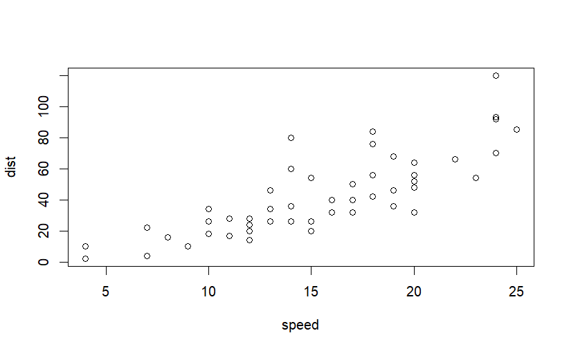

```r
plot(cars)
```

## Podstawowe funkcjonalności języka R

### Podstawa podstaw

Utworzenie zmiennej *x* i przypisanie do niej wartości *5:*

```r
x <- 5 # traktowany jako wektor długości 1
```

lub

```r
5 -> x
```

i zazwyczaj również

```r
x = 5 # a nawet assign("x", 5)
```

ale lepiej trzymać się *<-.*

### Co robi dana funkcja/obiekt/cokolwiek?

Aby dowiedzieć się, do czego przyda nam się na przykład funkcja *solve*, używamy:

```r
help(solve)
```

lub alternatywnie:

```r
?solve
```

### Typy zmiennych

R posiada 6 typów zmiennych:

- character

```r
typeof("string")
```

```
[1] "character"
```

- double

```r
typeof(2)
```

```
[1] "double"
```

```r
typeof(15.5)
```

```
[1] "double"
```

- integer

```r
typeof(2L)
```

```
[1] "integer"
```

- logical

```r
typeof(TRUE)
```

```
[1] "logical"
```

- complex

```r
typeof(1 + 4i)
```

```
[1] "complex"
```

- raw

```r
raw(length = 2) # do przechowywania bajtów
```

```
[1] 00 00
```

Typu *raw* prawdopodobnie nie użyjemy ani razu w trakcie tego kursu.

### Arytmetyka i wektory

```r
x <- c(1.0, 2.0, 2.5) # concatenate
print(x)
```

```
[1] 1.0 2.0 2.5
```

Aby nie powtarzać procesu *przypisz do zmiennej - wyprintuj ją*, możemy zwyczajnie napisać:

```r
c(1.0, 2.0, 2.5)
```

```
[1] 1.0 2.0 2.5
```

lub wraz z przypisaniem:

```r
(x <- c(1.0, 2.0, 2.5))
```

```
[1] 1.0 2.0 2.5
```

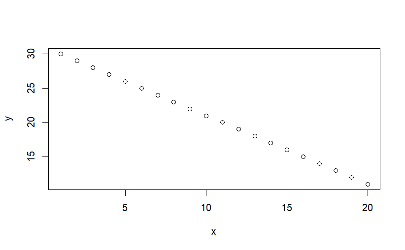

```r
x <- 1:20
y <- 30:11
plot(x, y) # funkcja wbudowana, która tworzy najprostszy wykres punktowy
```

```r
seq(-pi, pi, len = 5)
```

```
[1] -3.141593 -1.570796  0.000000  1.570796  3.141593
```

```r
seq(-pi, pi, by = pi)
```

```
[1] -3.141593  0.000000  3.141593
```

```r
rep(x, times = 2)
```

```
 [1]  1  2  3  4  5  6  7  8  9 10 11 12 13 14 15 16 17 18
[19] 19 20  1  2  3  4  5  6  7  8  9 10 11 12 13 14 15 16
[37] 17 18 19 20
```

```r
rep(x, each = 2)
```

```
 [1]  1  1  2  2  3  3  4  4  5  5  6  6  7  7  8  8  9  9
[19] 10 10 11 11 12 12 13 13 14 14 15 15 16 16 17 17 18 18
[37] 19 19 20 20
```

```r
x <- c(1, 2, 3, 4, 5, 6)
y <- c(1, 2)
2*x + y + 1
```

```
[1]  4  7  8 11 12 15
```

```r
log(x)
```

```
[1] 0.0000000 0.6931472 1.0986123 1.3862944 1.6094379
[6] 1.7917595
```

```r
exp(x)
```

```
[1]   2.718282   7.389056  20.085537  54.598150 148.413159
[6] 403.428793
```

```r
sin(x)
```

```
[1]  0.8414710  0.9092974  0.1411200 -0.7568025 -0.9589243
[6] -0.2794155
```

Aby usunąć zmienne *x* i y, wystarczy użyć*:*

```r
rm(x, y)
```

### Typy obiektów

*Macierze* (lub bardziej ogólnie *arrays*) - wielowymiarowe wektory przechowujące tylko jeden typ danych (tak samo jak wektory).

```r
c(1, "a") # castowanie do ogólniejszego typu
```

```
[1] "1" "a"
```

```r
x <- 1:20
dim(x) <- c(2, 5, 2) # zmieniamy jednowymiarowy wektor x na array o wymiarach 2 x 5 x 2
```

```r
x
```

```
, , 1

     [,1] [,2] [,3] [,4] [,5]
[1,]    1    3    5    7    9
[2,]    2    4    6    8   10

, , 2

     [,1] [,2] [,3] [,4] [,5]
[1,]   11   13   15   17   19
[2,]   12   14   16   18   20
```

```r
x[1, 1, 1]
```

```
[1] 1
```

```r
x[1,,]
```

```
     [,1] [,2]
[1,]    1   11
[2,]    3   13
[3,]    5   15
[4,]    7   17
[5,]    9   19
```

```r
x[,1,]
```

```
     [,1] [,2]
[1,]    1   11
[2,]    2   12
```

```r
x[,,1]
```

```
     [,1] [,2] [,3] [,4] [,5]
[1,]    1    3    5    7    9
[2,]    2    4    6    8   10
```

```r
array(1:20, c(2, 5, 2))
```

```
, , 1

     [,1] [,2] [,3] [,4] [,5]
[1,]    1    3    5    7    9
[2,]    2    4    6    8   10

, , 2

     [,1] [,2] [,3] [,4] [,5]
[1,]   11   13   15   17   19
[2,]   12   14   16   18   20
```

*Listy -* ogólniejsza forma wektorów, w których elementy również są uporządkowanie, ale nie muszą być tego samego typu:

```r
l <- list(name = "Jan", surname = "Wspaniały", no.children = 3, names.children = c("Asia", "Kuba"))
l
```

```
$name
[1] "Jan"

$surname
[1] "Wspaniały"

$no.children
[1] 3

$names.children
[1] "Asia" "Kuba"
```

```r
l[1]
```

```
$name
[1] "Jan"
```

```r
l[[1]]
```

```
[1] "Jan"
```

```r
l$name
```

```
[1] "Jan"
```

```r
l["name"]
```

```
$name
[1] "Jan"
```

```r
l$names.children[1]
```

```
[1] "Asia"
```

```r
l[[4]][1]
```

```
[1] "Asia"
```

```r
list("Jan", "Wspaniały")
```

```
[[1]]
[1] "Jan"

[[2]]
[1] "Wspaniały"
```

*Ramki danych* (*dataframe) -* macierzopodobne struktury, w których kolumny mogą mieć różne typy. Są więc zazwyczaj wykorzystywane do reprezentowania zbiorów danych, w których wiersz to pojedyncza obserwacja o pewnych wartościach zmiennych określanych przez kolumny.

```r
person <- c("Ania", "Hubert")
car_model <- c("Maluch", "Ferrari")
status <- c("Msc", "Bsc")
happy <- c(TRUE, FALSE)
df <- data.frame(person = person, car_model = car_model, status = status, happy = happy)
```

```r
df[, c("person", "happy")]
```

| person | happy |
| --- | --- |
| Ania | TRUE |
| Hubert | FALSE |

```r
head(df, 1)
```

|  | person | car_model | status | happy |
| --- | --- | --- | --- | --- |
| 1 | Ania | Maluch | Msc | TRUE |

```r
str(df)
```

```
'data.frame':   2 obs. of  4 variables:
 $ person   : chr  "Ania" "Hubert"
 $ car_model: chr  "Maluch" "Ferrari"
 $ status   : chr  "Msc" "Bsc"
 $ happy    : logi  TRUE FALSE
```

```r
df$person
```

```
[1] "Ania"   "Hubert"
```

```r
table(df)
```

```
, , status = Bsc, happy = FALSE

        car_model
person   Ferrari Maluch
  Ania         0      0
  Hubert       1      0

, , status = Msc, happy = FALSE

        car_model
person   Ferrari Maluch
  Ania         0      0
  Hubert       0      0

, , status = Bsc, happy = TRUE

        car_model
person   Ferrari Maluch
  Ania         0      0
  Hubert       0      0

, , status = Msc, happy = TRUE

        car_model
person   Ferrari Maluch
  Ania         0      1
  Hubert       0      0
```

```r
df$car_model == "Maluch"
```

```
[1]  TRUE FALSE
```

```r
df[df$car_model == "Maluch", "status"]
```

```
[1] "Msc"
```

### Czym są *factory*?

Factory to wektory określające grupowanie elementów innego obiektu tej samej długości.

```r
names <- c("Ania", "Tomek", "Kuba", "Marysia") # chcemy określić, które imiona pochodzą od mężczyzn, a które od kobiet
sex <- factor(c("K", "M", "M", "K"))
tapply(names, sex, c) # stosuje funkcję c (concatenate) do zmiennej names pogrupowanej względem factora sex
```

```
$K
[1] "Ania"    "Marysia"

$M
[1] "Tomek" "Kuba"
```

Przykład ten ma za zadanie pokazać zastosowanie *factorów*, ale wywołanie konstruktora *factor* w tym przypadku nie jest niezbędne:

```r
names <- c("Ania", "Tomek", "Kuba", "Marysia")
sex <- c("K", "M", "M", "K")
tapply(names, sex, c)
```

```
$K
[1] "Ania"    "Marysia"

$M
[1] "Tomek" "Kuba"
```

Przy okazji kolejnych laboratoriów *factory* będą pojawiać się regularnie i główny zysk z ich zastosowania wynikać będzie m.in. z tego, że każdy *factor* możemy podsumować za pomocą jego *leveli*, czyli unikalnych wartości.

```r
levels(factor(c("K", "M", "M", "K")))
```

```
[1] "K" "M"
```

### Funkcje

Funkcje tworzymy w następujący sposób:

```r
func <- function(x, y) {
  z <- x + y
  return(z)
}
z <- func(1, 2)
z
```

```
[1] 3
```

Gdy pominiemy *return(),* funkcja zwraca swoje ostatnie wyrażenie:

```r
func <- function(x, y) {
  z <- x + y
  z
}
func(2, 3)
```

```
[1] 5
```

### *apply()* i jego wariacje

Funkcje z rodziny *apply()* mają na celu zastąpić pętle *for* w działaniu na pewnej kolekcji obiektów, np. na macierzy.

```r
x <- matrix(1:4, 2, 2)
x
```

```
     [,1] [,2]
[1,]    1    3
[2,]    2    4
```

```r
apply(x, 1, sum) # obiekt, wymiar, funkcja
```

```
[1] 4 6
```

*lapply()* jest dostosowana do działania na listach i zwraca listę tej samej długości co wejściowa.

```r
movies <- list(movie = c("SPIDERMAN", "BATMAN", "VERTIGO", "CHINATOWN"))
lapply(movies, tolower) # obiekt, funkcja
```

```
$movie
[1] "spiderman" "batman"    "vertigo"   "chinatown"
```

*sapply()* - działa analogicznie do *lapply()*, ale zwraca wektor lub macierz.

```r
cars
```

| speed | dist |
| --- | --- |
| 4 | 2 |
| 4 | 10 |
| 7 | 4 |
| 7 | 22 |
| 8 | 16 |
| 9 | 10 |
| 10 | 18 |
| 10 | 26 |
| 10 | 34 |
| 11 | 17 |

[output cut: 40 more lines]

```r
lapply(cars, min) # obiekt, funkcja
```

```
$speed
[1] 4

$dist
[1] 2
```

```r
sapply(cars, min) # obiekt, funkcja
```

```
speed  dist
    4     2
```

```r
help(sapply)
```

*tapply()* ma za zadanie wykonywać podaną przez użytkownika funkcję osobno dla każdego factora obecnego w podanym obiekcie.

```r
iris
```

| Sepal.Length | Sepal.Width | Petal.Length | Petal.Width | Species |
| --- | --- | --- | --- | --- |
| 5.1 | 3.5 | 1.4 | 0.2 | setosa |
| 4.9 | 3.0 | 1.4 | 0.2 | setosa |
| 4.7 | 3.2 | 1.3 | 0.2 | setosa |
| 4.6 | 3.1 | 1.5 | 0.2 | setosa |
| 5.0 | 3.6 | 1.4 | 0.2 | setosa |
| 5.4 | 3.9 | 1.7 | 0.4 | setosa |
| 4.6 | 3.4 | 1.4 | 0.3 | setosa |
| 5.0 | 3.4 | 1.5 | 0.2 | setosa |
| 4.4 | 2.9 | 1.4 | 0.2 | setosa |
| 4.9 | 3.1 | 1.5 | 0.1 | setosa |

[output cut: 140 more lines]

```r
tapply(iris$Sepal.Width, iris$Species, median) # obiekt, lista factorów, funkcja
```

```
    setosa versicolor  virginica
       3.4        2.8        3.0
```

### Wyrażenia *if/else,* których się nie boimy

Wyrażenia *if/else* konstruujemy w następujący sposób:

```r
b <- TRUE
if (b == TRUE) {
  print("I'm not scared of using an if/else statement")
} else {
  print("Please, no more if/else statements")
}
```

```
[1] "I'm not scared of using an if/else statement"
```

Przy okazji małe uproszczenie:

```r
if (b) {
  print("I'm not scared of using an if/else statement")
} else {
  print("Please, no more if/else statements")
}
```

```
[1] "I'm not scared of using an if/else statement"
```

### Pętle *for*, których też się nie boimy

Pętlę *for* tworzymy następująco:

```r
for (i in 1:10) {
  print(i)
}
```

```
[1] 1
[1] 2
[1] 3
[1] 4
[1] 5
[1] 6
[1] 7
[1] 8
[1] 9
[1] 10
```

Zagnieżdżone pętle:

```r
m <- matrix(1:9, nrow = 3, ncol = 3)

for (row in 1:nrow(m)) {
    for (col in 1:ncol(m)) {
        print(paste('Row', row, 'col', col, 'value', m[row, col]))
    }
}
```

```
[1] "Row 1 col 1 value 1"
[1] "Row 1 col 2 value 4"
[1] "Row 1 col 3 value 7"
[1] "Row 2 col 1 value 2"
[1] "Row 2 col 2 value 5"
[1] "Row 2 col 3 value 8"
[1] "Row 3 col 1 value 3"
[1] "Row 3 col 2 value 6"
[1] "Row 3 col 3 value 9"
```

Wyrażenie *break* przerywa pętlę.

```r
for (i in 1:5) {
  if (i > 3) {
    print("End")
    break
  } else {
    print(i)
  }
}
```

```
[1] 1
[1] 2
[1] 3
[1] "End"
```

Wyrażenie *next* pomija aktualny krok.

```r
for (i in 1:5) {
  if (i == 3) {
    print("Skip")
    next
  } else {
    print(i)
  }
}
```

```
[1] 1
[1] 2
[1] "Skip"
[1] 4
[1] 5
```

Możemy również używać pętli *repeat:*

```r
i <- 1
repeat {
  print(i)
  i <- i + 1
  if (i == 3) {
    break
  }
}
```

```
[1] 1
[1] 2
```

oraz *while:*

```r
i <- 1
while (i < 5) {
  print(i)
  i <- i + 1
}
```

```
[1] 1
[1] 2
[1] 3
[1] 4
```